# AD project notebook - expression data

Ian Brettell

Initial setup:

```r
install.packages("here")
install.packages("tidyverse", dependencies = TRUE)
install.packages("rafalib")
install.packages("dummies")
source("https://bioconductor.org/biocLite.R")
biocLite("limma")
install.packages("yaml")
install.packages("backports")
install.packages("reshape2")
install.packages("viridis")
biocLite("made4")
install.packages("caret")
install.packages('e1071', dependencies=TRUE)
install.packages("ggfortify")
install.packages("cluster")
install.packages("factoextra")
biocLite("Biobase")
biocLite("limma")
biocLite("pd.huex.1.0.st.v2")
biocLite("huex10sttranscriptcluster.db")
install.packages("VennDiagram")
install.packages("Grid")
biocLite("gage")
biocLite("GSEABase")
biocLite("KEGGREST")

# Note: Installing bioconductor created issues with creating the markdown preview, which appears to be fixed by installing the `yaml`, `backports` and `reshape2` packages afterwards.
```

*19 December 2017*

## Run analysis on expression data

I was using the wrong ID data - we will run the above again substituting the correct data.

### 2.1. Import files

```r
exdata <- read.delim("C:/Users/bre227/Dropbox/eQTL/Data/AIBL_expression_set/AIBL_Gene_Expression.txt", sep = "", header = T)
dim(exdata)
```

```
[1] 22011   218
```

```r
head(exdata)
```

|  | X100 | X102 | X103 | X104 | X105 | X106 | X107 | X108 | X109 | X111 | X112 | X114 | X115 | X116 | X117 | X118 | X121 | X123 | X124 | X125 | X126 | X127 | X128 | X129 | X130 | X135 | X136 | X139 | X140 | … |
| --- | --- | --- | --- | --- | --- | --- | --- | --- | --- | --- | --- | --- | --- | --- | --- | --- | --- | --- | --- | --- | --- | --- | --- | --- | --- | --- | --- | --- | --- | --- |
| 2315554 | 6.030619 | 6.165575 | 6.573792 | 6.489151 | 6.167301 | 6.162833 | 6.459433 | 6.500313 | 5.758869 | 6.255258 | 6.283379 | 6.346622 | 6.288157 | 5.949029 | 6.314319 | 5.968143 | 6.493032 | 6.167725 | 6.406573 | 5.849523 | 6.502011 | 6.135674 | 6.461849 | 6.036305 | 6.268364 | 6.323187 | 5.928358 | 5.966071 | 5.944790 | … |
| 2315633 | 6.540337 | 6.696329 | 7.037530 | 6.707376 | 6.604118 | 6.799695 | 6.796057 | 6.952976 | 6.401347 | 6.709539 | 6.765484 | 6.880260 | 6.912437 | 6.581726 | 6.779152 | 6.700227 | 7.002052 | 6.650965 | 6.689737 | 6.586282 | 6.825250 | 6.731264 | 6.400309 | 6.688572 | 6.526505 | 6.939356 | 6.802994 | 6.561388 | 6.690265 | … |
| 2315674 | 6.294170 | 6.295077 | 6.636816 | 6.504605 | 6.381816 | 6.459972 | 6.526122 | 6.675960 | 5.973544 | 6.444970 | 6.495661 | 6.345604 | 6.307653 | 6.153074 | 6.349589 | 6.380947 | 6.738490 | 6.341245 | 6.611027 | 6.054108 | 6.471669 | 6.309723 | 6.723188 | 6.164308 | 6.445091 | 6.567885 | 6.246338 | 6.119326 | 6.218748 | … |
| 2315739 | 6.049571 | 6.232016 | 6.381600 | 6.273409 | 6.381270 | 6.704779 | 6.514058 | 6.542828 | 6.042320 | 6.591385 | 6.424220 | 6.468000 | 6.363114 | 6.331987 | 6.252506 | 6.624148 | 6.578067 | 6.318249 | 6.720172 | 6.266113 | 6.580387 | 6.357371 | 6.617919 | 6.484227 | 6.197191 | 6.548507 | 6.294528 | 6.148482 | 6.373590 | … |
| 2315894 | 8.438639 | 8.290235 | 7.875573 | 8.596950 | 8.076391 | 8.590583 | 8.658526 | 8.538429 | 8.042496 | 8.389016 | 8.395555 | 8.143446 | 8.533878 | 8.352128 | 8.635744 | 8.154736 | 8.828091 | 8.426085 | 8.717953 | 8.082044 | 8.465663 | 8.256031 | 8.555241 | 8.350568 | 8.188000 | 8.399823 | 8.458825 | 8.317301 | 8.380272 | … |
| 2315918 | 6.053986 | 5.378146 | 5.618119 | 6.507528 | 5.840277 | 5.982190 | 6.296157 | 6.060075 | 5.274647 | 5.353105 | 5.346982 | 6.054692 | 6.041754 | 6.182786 | 6.440316 | 5.940083 | 5.703004 | 4.631404 | 6.257573 | 5.547268 | 5.962815 | 4.841692 | 5.396958 | 6.009194 | 6.148451 | 6.382298 | 5.523462 | 5.866791 | 5.396945 | … |

```r
metadata <- read.delim("~/R/AD_project/Data/Expression/aibl-ids-6.0.0-201712010300.txt", sep = "\t", header = T)
dim(metadata)
```

```
[1] 6863 1174
```

```r
head(metadata)
```

|  | AIBL.Id | Collection | Enrolment | Recruitment | Actigraph.Light | Actigraph.Medium | Actigraph.Hard | Actigraph.Very.Hard | Actigraph.Avg.Counts | Actigraph.Peak.Counts | Actigraph.TC.Daily..x.10.4. | Actigraph.K.Cal.Daily | CSF.Date.of.CSF | CSF.Ab42_INNX_MELB | CSF.Tau_INNX_MELB | CSF.pTAU181_INNX_MELB | CSF.Ratio_Ab42_Tau_INNX_MELB | CSF.Ratio_Ab42_pTau181_INNX_MELB | Demographic.Sex | Demographic.YearMonthOfBirth | Demographic.Classification | Demographic.Site | Demographic.Testing.Venue | Demographic.Consented | Demographic.Age.at.consent | Demographic.Demographic.Changes | Demographic.Current.Marital.Status | Demographic.Primary.Occupation | Demographic.Prim.Occ.Details | … |
| --- | --- | --- | --- | --- | --- | --- | --- | --- | --- | --- | --- | --- | --- | --- | --- | --- | --- | --- | --- | --- | --- | --- | --- | --- | --- | --- | --- | --- | --- | --- |
| 1 | 2 | 1 | AIBL Inception Cohort | AIBL | NA | NA | NA | NA | NA | NA | NA | NA |  | NA | NA | NA | NA | NA | Male | 194108 | NA | Melbourne |  | NA | NA | NA | Married | Other | minister | … |
| 2 | 2 | 2 | AIBL Inception Cohort | AIBL | NA | NA | NA | NA | NA | NA | NA | NA |  | NA | NA | NA | NA | NA | Male | 194108 | NA | Melbourne |  | NA | NA | NA | Married | Other | minister | … |
| 3 | 2 | 3 | AIBL Inception Cohort | AIBL | NA | NA | NA | NA | NA | NA | NA | NA |  | NA | NA | NA | NA | NA | Male | 194108 | NA | Melbourne |  | NA | NA | NA | Married | Other | minister | … |
| 4 | 2 | 4 | AIBL Inception Cohort | AIBL | NA | NA | NA | NA | NA | NA | NA | NA |  | NA | NA | NA | NA | NA | Male | 194108 | NA | Melbourne |  | NA | NA | NA | Married | Other | minister | … |
| 5 | 2 | 5 | AIBL Inception Cohort | AIBL | NA | NA | NA | NA | NA | NA | NA | NA |  | NA | NA | NA | NA | NA | Male | 194108 | NA | Melbourne |  | NA | NA | NA | Married | Other | minister | … |
| 6 | 2 | 6 | AIBL Inception Cohort | AIBL | NA | NA | NA | NA | NA | NA | NA | NA |  | NA | NA | NA | NA | NA | Male | 194108 | NA | Melbourne |  | NA | NA | NA | Married | Other | minister | … |

```r
ids2 <- read.delim("C:/Users/bre227/Dropbox/eQTL/Data/AIBL_expression_set/AIBL_Gene_Expression_IDs_UpdtdDec2017.txt", sep = " ")
colnames(exdata) <- as.vector(ids2$x) # replace colnames with ids2
# filter for those in ids2
metadata2 <- metadata[(metadata$AIBL.Id %in% ids2$x) & (metadata$Collection == "1"), ]
dim(metadata2)
```

```
[1]  218 1174
```

### 2.2. Tidy and combine data

Load packages

```r
library(tidyverse)
```

Add age column and apoe4 columns

```r
metadata2$Age <- as.numeric((as.Date(metadata2$Progress.Summary.Date.of.NP.assessment,format=c("%d/%m/%Y")))-(as.Date(paste("15",substr(metadata2$Demographic.YearMonthOfBirth,start=5,stop=6),substr(metadata2$Demographic.YearMonthOfBirth,start=1,stop=4),sep="/"),format = c("%d/%m/%Y"))))/365.25
summary(metadata2$Age)
```

```
   Min. 1st Qu.  Median    Mean 3rd Qu.    Max.
  55.15   65.86   72.34   72.44   78.54   91.79
```

Histogram of age

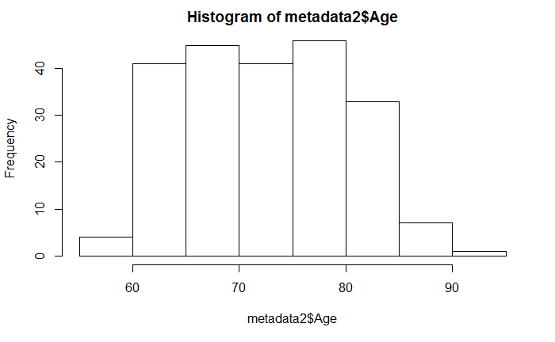

```r
hist(metadata2$Age)
```

```r
unique(metadata2$Demographic.ApoE.genotype)
```

```
[1] E3/E3 E4/E3 E4/E2 E3/E2 E4/E4 E2/E2
Levels:  E2/E2 E3/E2 E3/E3 E4/E2 E4/E3 E4/E4
```

```r
metadata2$apoe4 <- as.factor(ifelse(metadata2$Demographic.ApoE.genotype=="E2/E2"|metadata2$Demographic.ApoE.genotype=="E3/E2"|metadata2$Demographic.ApoE.genotype=="E3/E3",0,ifelse(metadata2$Demographic.ApoE.genotype=="E4/E2"|metadata2$Demographic.ApoE.genotype=="E4/E3"|metadata2$Demographic.ApoE.genotype=="E4/E4",1,NA)))
metadata2 %>%
  group_by(apoe4) %>%
  summarise(no_rows = length(apoe4))
```

| apoe4 | no_rows |
| --- | --- |
| 0 | 115 |
| 1 | 103 |

Create binary PET status

```r
metadata2$PET <- as.factor(ifelse(metadata2$Image.PET.Amyloid.PIB_NAV.Status == "Positive" | metadata2$Image.PET.Amyloid.Florbetapir.Status== "Positive" | metadata2$Image.PET.Amyloid.Flutemetamol.Status == "Positive", "POS", ifelse(metadata2$Image.PET.Amyloid.PIB_NAV.Status == "Negative" | metadata2$Image.PET.Amyloid.Florbetapir.Status== "Negative" | metadata2$Image.PET.Amyloid.Flutemetamol.Status == "Negative", "NEG",NA)))
metadata2 %>%
  group_by(PET) %>%
  summarise(no_rows = length(PET))
```

| PET | no_rows |
| --- | --- |
| NEG | 94 |
| POS | 102 |
| NA | 22 |

Extract metadata for columns of interest

```r
meta2 <- dplyr::select(metadata2,
                AIBL.Id,
                Demographic.Sex,
                PET,
                apoe4,
                Age)
write.table(meta2, "C:/Users/bre227/Documents/R/AD_project/Working/key_metadata.txt", col.names = T, row.names = F, quote = F, sep = "\t")
```

### 2.3. Create initial exploratory plots

Plot for whole dataset

```r
exdata1 <- as_tibble(exdata)
exdata1 <- as_tibble(t(exdata1)) # transpose to put samples in rows, genes in columns
colnames(exdata1) <- rownames(exdata) # add genes names
exdata1$AIBL.Id <- as.integer(colnames(exdata)) # add 'AIBL.Id' column
exdata2 <- left_join(meta2, exdata1, by = "AIBL.Id") %>%
  na.omit # add metadata and remove PET and apoe4 columns with 'NA'
rownames(exdata2) <- exdata2$AIBL.Id # to ensure the labels in the plots reflect the AIBL.Ids
dim(exdata2)
```

```
[1]   196 22016
```

Run PCA

```r
pca <- prcomp(exdata2[6:22016], center = T, scale. = T) # run PCA
```

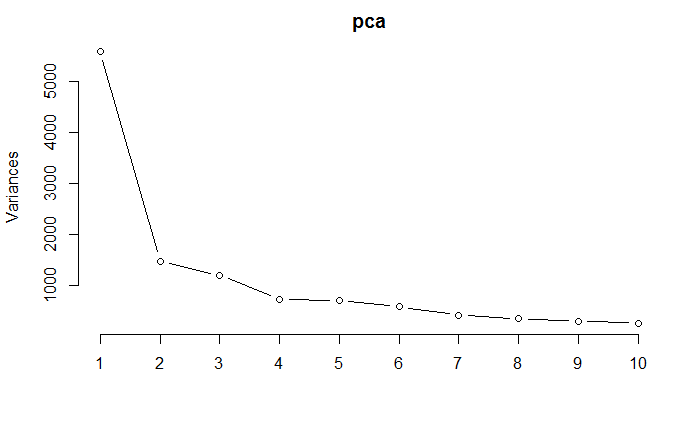

```r
plot(pca, type = "l")
```

Another, better version of the scree plot using the package `factoextra`.

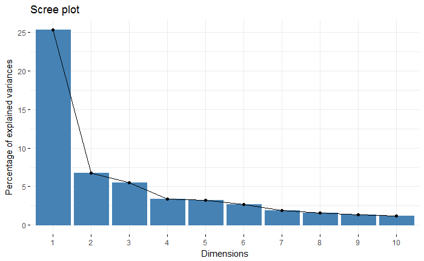

```r
library(factoextra)
fviz_eig(pca)
```

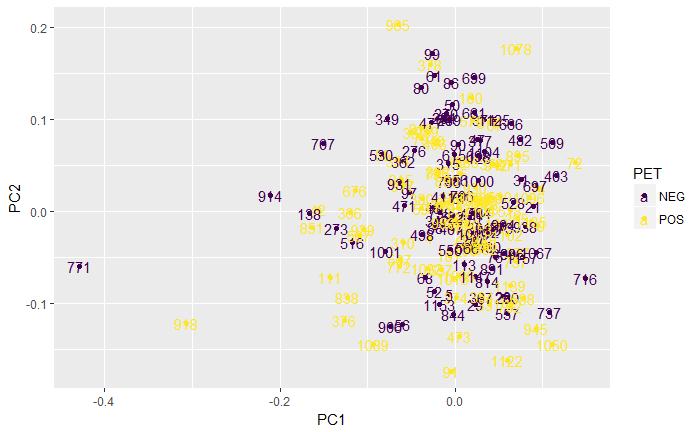

```r
library(ggfortify)
autoplot(pca, data = exdata2, colour = "PET", label = T) +
  viridis::scale_colour_viridis(option = "viridis", discrete = T)
```

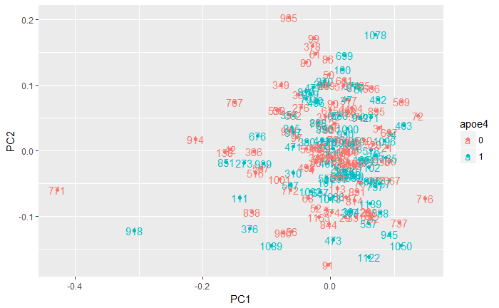

```r
library(ggfortify)
autoplot(pca, data = exdata2, colour = "apoe4", label = T)
```

*Consider excluding outlier individuals with AIBL.Ids 771 and 918.*

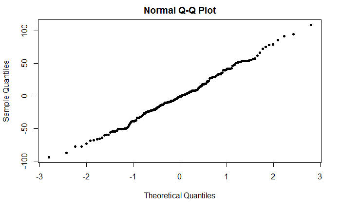

```r
qqnorm(pca$x[,2], pch = 20)
```

### 2.4. Use `limma` to analyse expression data.

We first create an ‘ExpressionSet’ with genes on rows, and samples on columns, following the guide here: https://www.bioconductor.org/packages/3.7/bioc/vignettes/Biobase/inst/doc/ExpressionSetIntroduction.pdf

```r
library(Biobase)
```

```r
exprs <- as.matrix(t(exdata2[,6:22016])) # leaving behind the first 5 metadata columns
minimalSet <- ExpressionSet(assayData = exprs)
pData <- exdata2[,1:5]
summary(pData)
```

```
    AIBL.Id       Demographic.Sex  PET      apoe4        Age
 Min.   :   4.0   Female:98       NEG: 94   0:107   Min.   :55.15
 1st Qu.: 110.8   Male  :98       POS:102   1: 89   1st Qu.:66.97
 Median : 482.5                                     Median :72.56
 Mean   : 511.7                                     Mean   :72.72
 3rd Qu.: 839.5                                     3rd Qu.:78.89
 Max.   :1174.0                                     Max.   :91.79
```

```r
library(limma)
```

```r
PET_apoe4 <- paste(pData$PET, pData$apoe4, sep = ".") # put PET/apoe4 combinations into a vector
PET_apoe4
```

```
  [1] "POS.0" "NEG.0" "POS.1" "POS.1" "NEG.0" "NEG.0" "POS.0" "POS.0" "POS.1" "NEG.0" "NEG.0" "POS.1" "POS.0"
 [14] "POS.0" "POS.1" "POS.0" "NEG.0" "NEG.1" "NEG.0" "NEG.0" "POS.1" "POS.0" "NEG.0" "POS.1" "POS.0" "POS.0"
 [27] "NEG.0" "POS.0" "NEG.0" "POS.1" "NEG.1" "NEG.0" "POS.0" "NEG.0" "POS.1" "NEG.0" "NEG.0" "NEG.0" "NEG.0"
 [40] "NEG.0" "POS.0" "NEG.0" "NEG.0" "POS.1" "POS.1" "POS.1" "POS.1" "NEG.0" "NEG.0" "POS.1" "POS.1" "NEG.0"
 [53] "POS.0" "NEG.0" "NEG.0" "NEG.0" "POS.1" "NEG.1" "NEG.1" "NEG.0" "POS.1" "POS.1" "NEG.0" "NEG.1" "NEG.0"
 [66] "NEG.1" "NEG.0" "POS.1" "NEG.0" "NEG.0" "POS.0" "NEG.0" "NEG.0" "POS.1" "NEG.0" "POS.1" "POS.0" "NEG.1"
 [79] "NEG.1" "POS.0" "POS.1" "POS.0" "POS.1" "POS.0" "POS.0" "POS.1" "POS.1" "NEG.1" "POS.1" "NEG.1" "POS.1"
 [92] "NEG.1" "NEG.1" "NEG.1" "POS.1" "NEG.1" "NEG.1" "NEG.1" "POS.0" "POS.1" "NEG.0" "POS.1" "NEG.0" "POS.0"
[105] "NEG.0" "POS.1" "NEG.0" "NEG.0" "NEG.1" "NEG.0" "NEG.1" "NEG.0" "POS.0" "POS.0" "NEG.0" "POS.1" "POS.1"
[118] "POS.1" "POS.0" "NEG.0" "POS.1" "POS.0" "NEG.0" "NEG.0" "POS.1" "NEG.1" "NEG.0" "NEG.0" "NEG.1" "POS.0"
[131] "NEG.0" "NEG.0" "NEG.0" "NEG.0" "NEG.0" "POS.1" "NEG.0" "POS.0" "NEG.0" "POS.0" "NEG.0" "NEG.0" "POS.1"
[144] "NEG.0" "POS.1" "POS.1" "POS.0" "NEG.0" "POS.1" "POS.1" "POS.1" "NEG.0" "POS.0" "NEG.1" "NEG.0" "NEG.0"
[157] "POS.1" "POS.1" "POS.1" "NEG.0" "NEG.0" "POS.1" "POS.1" "POS.1" "POS.1" "POS.1" "POS.0" "POS.1" "POS.1"
[170] "POS.0" "POS.0" "NEG.1" "NEG.0" "NEG.0" "POS.1" "POS.1" "POS.1" "POS.1" "NEG.0" "POS.1" "POS.1" "POS.0"
[183] "POS.1" "POS.1" "POS.1" "POS.1" "NEG.0" "POS.0" "POS.1" "NEG.0" "POS.1" "POS.1" "NEG.0" "NEG.0" "NEG.1"
[196] "POS.0"
```

```r
PET_apoe4 <- factor(PET_apoe4, levels = c(unique(PET_apoe4))) # turn it into a factor
design <- model.matrix(~0 + PET_apoe4) # create factor table for four combinations
colnames(design) <- levels(PET_apoe4)
fit <- lmFit(exprs, design)
```

Set four pair-wise contrasts of interest and compute the contrasts and moderated t-tests.

```r
cont.matrix <- makeContrasts(apoe4_for_PET_yes = POS.1 - POS.0,
                             apoe4_for_PET_no = NEG.1 - NEG.0,
                             PET_for_apoe4_yes = POS.1 - NEG.1,
                             PET_for_apoe4_no = POS.0 - NEG.0,
                             levels = design)
fit2 <- contrasts.fit(fit, cont.matrix)
fit2 <- eBayes(fit2)
```

Get the genes differentially expressed in each comparison

```r
topTable(fit2, coef = "apoe4_for_PET_yes")
```

|  | logFC | AveExpr | t | P.Value | adj.P.Val | B |
| --- | --- | --- | --- | --- | --- | --- |
| 2844265 | -0.1571673 | 9.658723 | -3.618883 | 0.0003765553 | 0.9997963 | -0.2362071 |
| 3057499 | -0.2441851 | 7.949596 | -3.581096 | 0.0004315160 | 0.9997963 | -0.3409662 |
| 2858023 | -0.4731343 | 5.975103 | -3.528415 | 0.0005208277 | 0.9997963 | -0.4854432 |
| 3551831 | -0.3588234 | 9.048605 | -3.420162 | 0.0007614899 | 0.9997963 | -0.7765350 |
| 2777276 | -0.1110723 | 4.030217 | -3.400722 | 0.0008144670 | 0.9997963 | -0.8279784 |
| 2901767 | -0.3038063 | 3.331505 | -3.393114 | 0.0008361228 | 0.9997963 | -0.8480418 |
| 3175971 | 0.2603176 | 4.927601 | 3.392261 | 0.0008385844 | 0.9997963 | -0.8502890 |
| 2949093 | -0.3140418 | 8.168469 | -3.391025 | 0.0008421622 | 0.9997963 | -0.8535436 |
| 3201359 | 0.1125374 | 3.327325 | 3.346713 | 0.0009802920 | 0.9997963 | -0.9695617 |
| 3035892 | -0.1542426 | 6.302042 | -3.320263 | 0.0010725313 | 0.9997963 | -1.0381775 |

```r
topTable(fit2, coef = "apoe4_for_PET_no")
```

|  | logFC | AveExpr | t | P.Value | adj.P.Val | B |
| --- | --- | --- | --- | --- | --- | --- |
| 3200040 | 0.4619743 | 6.014835 | 3.778167 | 0.0002095318 | 0.8089319 | 0.006753974 |
| 2742935 | -0.1145487 | 3.419926 | -3.669926 | 0.0003127208 | 0.8089319 | -0.283863483 |
| 2450668 | -0.1567656 | 6.338712 | -3.665850 | 0.0003174169 | 0.8089319 | -0.294668121 |
| 3556755 | -0.5172788 | 5.253895 | -3.528763 | 0.0005201838 | 0.8089319 | -0.652149226 |
| 2432714 | 0.3713809 | 6.709923 | 3.486297 | 0.0006044289 | 0.8089319 | -0.760534696 |
| 2992936 | -0.1730552 | 5.024798 | -3.484046 | 0.0006092339 | 0.8089319 | -0.766248867 |
| 2326912 | -0.1126669 | 6.461992 | -3.363517 | 0.0009255923 | 0.8089319 | -1.067552716 |
| 2441220 | 0.4580489 | 7.145356 | 3.348988 | 0.0009727126 | 0.8089319 | -1.103254390 |
| 2708203 | -0.1565048 | 6.516957 | -3.312691 | 0.0011003925 | 0.8089319 | -1.191861230 |
| 3233049 | 0.3934480 | 5.500112 | 3.273517 | 0.0012556080 | 0.8089319 | -1.286546720 |

```r
topTable(fit2, coef = "PET_for_apoe4_yes")
```

|  | logFC | AveExpr | t | P.Value | adj.P.Val | B |
| --- | --- | --- | --- | --- | --- | --- |
| 3556755 | 0.5900021 | 5.253895 | 3.988073 | 9.400617e-05 | 0.9185737 | 0.5725079 |
| 2439842 | 0.2841407 | 11.020912 | 3.543879 | 4.929568e-04 | 0.9185737 | -0.6258639 |
| 3556130 | 0.3780847 | 3.274606 | 3.482533 | 6.124827e-04 | 0.9185737 | -0.7819824 |
| 3200134 | -0.6235077 | 4.664755 | -3.478271 | 6.217251e-04 | 0.9185737 | -0.7927434 |
| 3200040 | -0.4259823 | 6.014835 | -3.451967 | 6.817148e-04 | 0.9185737 | -0.8588988 |
| 2461473 | -0.1387253 | 7.518517 | -3.382351 | 8.676814e-04 | 0.9185737 | -1.0319048 |
| 3275574 | -0.4584030 | 3.954463 | -3.313979 | 1.095604e-03 | 0.9185737 | -1.1988486 |
| 2960399 | 0.1996480 | 4.609699 | 3.293751 | 1.173056e-03 | 0.9185737 | -1.2476724 |
| 3212360 | -0.3353887 | 7.013178 | -3.271133 | 1.265681e-03 | 0.9185737 | -1.3019568 |
| 2674337 | -0.3629145 | 5.590814 | -3.154954 | 1.858276e-03 | 0.9185737 | -1.5756240 |

```r
topTable(fit2, coef = "PET_for_apoe4_no")
```

|  | logFC | AveExpr | t | P.Value | adj.P.Val | B |
| --- | --- | --- | --- | --- | --- | --- |
| 2968279 | -0.4734721 | 4.164086 | -4.146137 | 5.031923e-05 | 0.9998206 | 1.3410708 |
| 3589458 | 0.6786763 | 8.914401 | 3.926100 | 1.195102e-04 | 0.9998206 | 0.6667804 |
| 2858023 | 0.4737473 | 5.975103 | 3.577728 | 4.367642e-04 | 0.9998206 | -0.3378800 |
| 2840770 | 0.2871089 | 7.194545 | 3.576530 | 4.386465e-04 | 0.9998206 | -0.3411999 |
| 3676723 | 0.3528242 | 6.657759 | 3.477264 | 6.239277e-04 | 0.9998206 | -0.6128369 |
| 3035892 | 0.1550655 | 6.302042 | 3.380251 | 8.739675e-04 | 0.9998206 | -0.8719226 |
| 2824315 | -0.2469625 | 7.159624 | -3.345071 | 9.857940e-04 | 0.9998206 | -0.9642980 |
| 3740574 | 0.5307678 | 5.825516 | 3.307736 | 1.118985e-03 | 0.9998206 | -1.0614122 |
| 3465409 | 0.1216811 | 10.439416 | 3.288708 | 1.193145e-03 | 0.9998206 | -1.1105401 |
| 3578069 | 0.1813540 | 5.926640 | 3.258079 | 1.322192e-03 | 0.9998206 | -1.1890973 |

```r
res1 <- topTable(fit2, coef = "apoe4_for_PET_yes", n = Inf)
res2 <- topTable(fit2, coef = "apoe4_for_PET_no", n = Inf)
res3 <- topTable(fit2, coef = "PET_for_apoe4_yes", n = Inf)
res4 <- topTable(fit2, coef = "PET_for_apoe4_no", n = Inf)
length(which(res1$P.Value < 0.05))
```

```
[1] 653
```

```r
length(which(res2$P.Value < 0.05))
```

```
[1] 684
```

```r
length(which(res3$P.Value < 0.05))
```

```
[1] 924
```

```r
length(which(res4$P.Value < 0.05))
```

```
[1] 769
```

```r
signif_apoe4_for_PET_yes <- filter(res1, P.Value < 0.05)
signif_apoe4_for_PET_no <- filter(res2, P.Value < 0.05)
signif_PET_for_apoe4_yes <- filter(res3, P.Value < 0.05)
signif_PET_for_apoe4_no <- filter(res4, P.Value < 0.05)
```

–>

Get list of genes that show significantly different expression between contrasts

```r
exdata3 <- dplyr::filter(exdata2, AIBL.Id != "771" & AIBL.Id != "914" & AIBL.Id != "918")
```

*20 December 2017*

Test to see whether the number of statistically significant genes changes when we exclude the outliers (AIBL.Ids **771**, **914** and **918**)

```r
pca2 <- prcomp(exdata3[6:22016], center = T, scale. = T) # run PCA
```

Run PCA

[figure not shown]

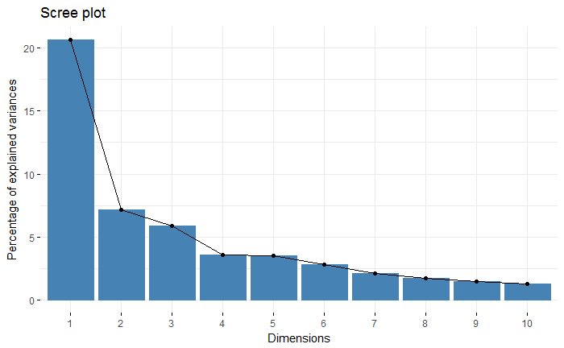

```r
library(factoextra)
fviz_eig(pca2)
```

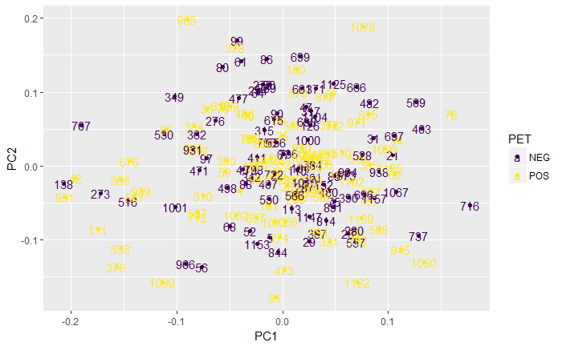

```r
library(ggfortify)
autoplot(pca2, data = exdata3, colour = "PET", label = T, label.label = "AIBL.Id") +
  viridis::scale_colour_viridis(option = "viridis", discrete = T)
```

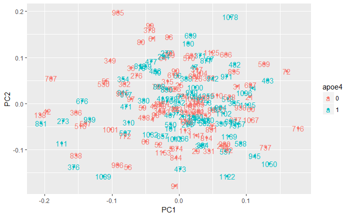

```r
library(ggfortify)
autoplot(pca2, data = exdata3, colour = "apoe4", label = T, label.label = "AIBL.Id")
```

```r
library(ggfortify)
autoplot(pca2, data = exdata3, colour = "apoe4", label = T, label.label = "AIBL.Id")
```

```r
exprs <- as.matrix(t(exdata3[,6:22016])) # leaving behind the first 5 metadata columns
minimalSet <- ExpressionSet(assayData = exprs)
pData <- exdata3[,1:5]
summary(pData)
```

```r
library(limma)
```

```r
PET_apoe4 <- paste(pData$PET, pData$apoe4, sep = ".") # put PET/apoe4 combinations into a vector
PET_apoe4
PET_apoe4 <- factor(PET_apoe4, levels = c(unique(PET_apoe4))) # turn it into a factor
design <- model.matrix(~0 + PET_apoe4) # create factor table for four combinations
colnames(design) <- levels(PET_apoe4)
fit <- lmFit(exprs, design)
```

```r
cont.matrix <- makeContrasts(apoe4_for_PET_yes = POS.1 - POS.0,
                             apoe4_for_PET_no = NEG.1 - NEG.0,
                             PET_for_apoe4_yes = POS.1 - NEG.1,
                             PET_for_apoe4_no = POS.0 - NEG.0,
                             levels = design)
fit2 <- contrasts.fit(fit, cont.matrix)
fit2 <- eBayes(fit2)
```

Set four pair-wise contrasts of interest and compute the contrasts and moderated t-tests.

```r
topTable(fit2, coef = "apoe4_for_PET_yes")
```

|  | logFC | AveExpr | t | P.Value | adj.P.Val | B |
| --- | --- | --- | --- | --- | --- | --- |
| 3057499 | -0.2531323 | 7.942998 | -3.739391 | 0.0002431584 | 0.9999956 | 0.1601894 |
| 2777276 | -0.1153798 | 4.025781 | -3.628561 | 0.0003650086 | 0.9999956 | -0.1588115 |
| 2901767 | -0.3193046 | 3.327466 | -3.583899 | 0.0004287991 | 0.9999956 | -0.2850568 |
| 2844265 | -0.1509818 | 9.656332 | -3.567604 | 0.0004545818 | 0.9999956 | -0.3307862 |
| 2409368 | -0.1338344 | 6.286659 | -3.562072 | 0.0004636617 | 0.9999956 | -0.3462708 |
| 3666686 | 0.1978885 | 9.056155 | 3.501101 | 0.0005756887 | 0.9999956 | -0.5155575 |
| 2858023 | -0.4611552 | 5.988824 | -3.442906 | 0.0007058991 | 0.9999956 | -0.6747915 |
| 3035892 | -0.1588230 | 6.299031 | -3.437255 | 0.0007199155 | 0.9999956 | -0.6901311 |
| 3551831 | -0.3304423 | 9.071120 | -3.419833 | 0.0007647847 | 0.9999956 | -0.7372851 |
| 3201359 | 0.1105071 | 3.322606 | 3.387895 | 0.0008539087 | 0.9999956 | -0.8231898 |

```r
topTable(fit2, coef = "apoe4_for_PET_no")
```

|  | logFC | AveExpr | t | P.Value | adj.P.Val | B |
| --- | --- | --- | --- | --- | --- | --- |
| 3200040 | 0.4528936 | 6.019464 | 3.681655 | 0.0003008101 | 0.9887579 | -0.1782252 |
| 2742935 | -0.1061671 | 3.415213 | -3.564236 | 0.0004600895 | 0.9887579 | -0.4933105 |
| 2450668 | -0.1392741 | 6.329673 | -3.536298 | 0.0005082548 | 0.9887579 | -0.5670018 |
| 3556755 | -0.5140861 | 5.246536 | -3.503791 | 0.0005702530 | 0.9887579 | -0.6521248 |
| 2432714 | 0.3465566 | 6.724809 | 3.339584 | 0.0010073308 | 0.9887579 | -1.0717772 |
| 3470410 | -0.4216059 | 6.235460 | -3.276050 | 0.0012483795 | 0.9887579 | -1.2294632 |
| 2326912 | -0.1047003 | 6.456753 | -3.268202 | 0.0012816292 | 0.9887579 | -1.2487602 |
| 2708203 | -0.1477474 | 6.509541 | -3.266396 | 0.0012893921 | 0.9887579 | -1.2531927 |
| 2992936 | -0.1573005 | 5.018443 | -3.266110 | 0.0012906267 | 0.9887579 | -1.2538951 |
| 2441220 | 0.4419378 | 7.154548 | 3.219147 | 0.0015088154 | 0.9887579 | -1.3684477 |

```r
topTable(fit2, coef = "PET_for_apoe4_yes")
```

|  | logFC | AveExpr | t | P.Value | adj.P.Val | B |
| --- | --- | --- | --- | --- | --- | --- |
| 3556755 | 0.5751162 | 5.246536 | 3.889938 | 0.0001379913 | 0.9855869 | 0.3892248 |
| 3556130 | 0.3765824 | 3.275279 | 3.446604 | 0.0006968670 | 0.9855869 | -0.8087430 |
| 2439842 | 0.2763598 | 11.018142 | 3.440166 | 0.0007126623 | 0.9855869 | -0.8252307 |
| 3200040 | -0.4251673 | 6.019464 | -3.429979 | 0.0007383455 | 0.9855869 | -0.8512688 |
| 3200134 | -0.6102370 | 4.677174 | -3.399282 | 0.0008210748 | 0.9855869 | -0.9293295 |
| 2461473 | -0.1338296 | 7.522368 | -3.302904 | 0.0011405961 | 0.9855869 | -1.1704617 |
| 2960399 | 0.1881811 | 4.598284 | 3.292189 | 0.0011825201 | 0.9855869 | -1.1968978 |
| 2768056 | 0.1360168 | 3.702261 | 3.264059 | 0.0012995076 | 0.9855869 | -1.2659431 |
| 3275574 | -0.4471021 | 3.966126 | -3.251440 | 0.0013554128 | 0.9855869 | -1.2967498 |
| 2674337 | -0.3712341 | 5.594589 | -3.232545 | 0.0014433127 | 0.9855869 | -1.3426821 |

```r
topTable(fit2, coef = "PET_for_apoe4_no")
```

|  | logFC | AveExpr | t | P.Value | adj.P.Val | B |
| --- | --- | --- | --- | --- | --- | --- |
| 2968279 | -0.4953480 | 4.172462 | -4.331286 | 0.0000238259 | 0.5244318 | 2.01418365 |
| 3589458 | 0.6559717 | 8.928704 | 3.771159 | 0.0002160639 | 0.9992423 | 0.26387635 |
| 3934479 | 0.1183821 | 6.465840 | 3.693545 | 0.0002879732 | 0.9992423 | 0.03721613 |
| 2409368 | 0.1364132 | 6.286659 | 3.668811 | 0.0003152832 | 0.9992423 | -0.03417981 |
| 2840770 | 0.2881094 | 7.191929 | 3.576100 | 0.0004409628 | 0.9992423 | -0.29815995 |
| 3035892 | 0.1603754 | 6.299031 | 3.507277 | 0.0005632802 | 0.9992423 | -0.49038347 |
| 2858023 | 0.4504941 | 5.988824 | 3.398608 | 0.0008229842 | 0.9992423 | -0.78733392 |
| 3676723 | 0.3446931 | 6.657412 | 3.396681 | 0.0008284680 | 0.9992423 | -0.79252646 |
| 2834743 | -0.1629243 | 7.467131 | -3.392509 | 0.0008404589 | 0.9992423 | -0.80376067 |
| 3415193 | 0.1879718 | 6.390564 | 3.348727 | 0.0009764521 | 0.9992423 | -0.92092208 |

Get the genes differentially expressed in each comparison

```r
res1 <- topTable(fit2, coef = "apoe4_for_PET_yes", n = Inf)
res2 <- topTable(fit2, coef = "apoe4_for_PET_no", n = Inf)
res3 <- topTable(fit2, coef = "PET_for_apoe4_yes", n = Inf)
res4 <- topTable(fit2, coef = "PET_for_apoe4_no", n = Inf)
length(which(res1$P.Value < 0.05))
```

[output not shown]

```r
length(which(res2$P.Value < 0.05))
```

```
[1] 684
```

```r
length(which(res3$P.Value < 0.05))
```

```
[1] 924
```

```r
length(which(res4$P.Value < 0.05))
```

```
[1] 769
```

```r
for (i in ls(pattern = "res")){
  x <- get(i)
  x$probe_id <- rownames(x)
  assign(i, x)
}
```

Probe IDs are set in the ‘res’ data frames as rownames. Create separate column for rownames. Need to do it now, because when `filter()` is applied below, it removes the rownames.

```r
signif_apoe4_for_PET_yes <- filter(res1, P.Value < 0.05)
signif_apoe4_for_PET_no <- filter(res2, P.Value < 0.05)
signif_PET_for_apoe4_yes <- filter(res3, P.Value < 0.05)
signif_PET_for_apoe4_no <- filter(res4, P.Value < 0.05)
rm(list = ls(pattern = "res")) # remove results to clear working memory
```

Get list of genes that show significantly different expression between contrasts

```r
library(pd.huex.1.0.st.v2)
library(huex10sttranscriptcluster.db)
### pull gene symbols and match to probe ids to replace rownames ###
x <- huex10sttranscriptclusterSYMBOL
# Get the probe identifiers that are mapped to a gene symbol
mapped_probes <- mappedkeys(x)
# Convert to a list
xx <- as.list(x[mapped_probes])
if(length(xx) > 0) {
# Get the SYMBOL for the first five probes
xx[1:5]
# Get the first one
xx[[1]]
}
```

```
[1] "LOC102723600"
```

```r
xx1 <- as.matrix(unlist(xx))
# Get table of probes
gns <- rownames(exdata)
gnsl <- xx1[rownames(xx1) %in% gns]
length(gnsl)
```

```
[1] 14825
```

```r
### Find ENSEMBL IDs ###
x3 <- huex10sttranscriptclusterENSEMBL
# Get the entrez gene IDs that are mapped to an Ensembl ID
mapped_genes <- mappedkeys(x3)
# Convert to a list
xx3 <- as.list(x3[mapped_genes])
xx3.1 <- as.matrix(unlist(xx3))
ens <- xx3.1[rownames(xx3.1) %in% gns]
length(ens)
```

```
[1] 13991
```

```r
#[1] 14497
### Find Entrez IDs ###
x4 <- huex10sttranscriptclusterENTREZID
# Get the probe identifiers that are mapped to an ENTREZ Gene ID
mapped_probes <- mappedkeys(x4)
# Convert to a list
xx4 <- as.list(x4[mapped_probes])
xx4.1 <- as.matrix(unlist(xx4))
entz <- xx4.1[rownames(xx4.1) %in% gns]
length(entz)
```

```
[1] 14825
```

## 2.5 Get gene identifiers for microarray probes and identify significant genes.

*Used JD’s code from ‘AIBL_Gene_Expression_SetUp_Dec82017.R’*

```r
# find how many probes are annotated
length(which(pid_all$probe_id %in% rownames(exdata)))
```

```
[1] 14825
```

# 2.6. Match probes, gene symbols, Ensembl IDs, and Entrez IDs with the list of statistically significant genes.

Create data frame of all probe matches with identifiers

```r
signif_all <- dplyr::select(signif_apoe4_for_PET_yes, probe_id, P.Value) %>%
  full_join(dplyr::select(signif_apoe4_for_PET_no, probe_id, P.Value), by = "probe_id") %>%
  full_join(dplyr::select(signif_PET_for_apoe4_yes, probe_id, P.Value), by = "probe_id") %>%
  full_join(dplyr::select(signif_PET_for_apoe4_no, probe_id, P.Value), by = "probe_id") %>%
  rename(P.Value.c1 = "P.Value.x",
         P.Value.c2 = "P.Value.y",
         P.Value.c3 = "P.Value.x.x",
         P.Value.c4 = "P.Value.y.y")
```

```
Error in rename(., P.Value.c1 = "P.Value.x", P.Value.c2 = "P.Value.y",  :
  Some 'from' names in value not found on 'x': P.Value.c1, P.Value.c2, P.Value.c3, P.Value.c4
```

Combine lists of significant genes for each contrast. Note that combined counts of significant genes for all four contrasts is 3030.

```r
sig_all2 <- left_join(signif_all, pid_all, by = "probe_id")
```

Bind gene ids to ‘signif_all’

```r
length(setdiff(signif_all$probe_id, pid_all$probe_id))
```

```
[1] 1000
```

There are many NAs in the ‘gene_symbol’ column, even though there are 34,127 unique probe_ids in ‘pid_symb’ - one would think they would all be accounted for.

```r
length(which(signif_all$probe_id %in% pid_all$probe_id == "TRUE"))
```

```
[1] 1438
```

Shows that there are 1000 probe ids in ‘signif_all’ that are not in ‘pid_all’, i.e. they do not have any annotation data.

Confirmed by:

```r
length(setdiff(rownames(exdata), pid_symb$probe_id))
```

```
[1] 7186
```

So are all probe_ids in the expression data in ‘pid_symb’?

```r
length(which(rownames(exdata) %in% pid_all$probe_id == "TRUE"))
```

```
[1] 14825
```

7,186/22,011 probes are not accounted for in the annotation data?

Confirm this:

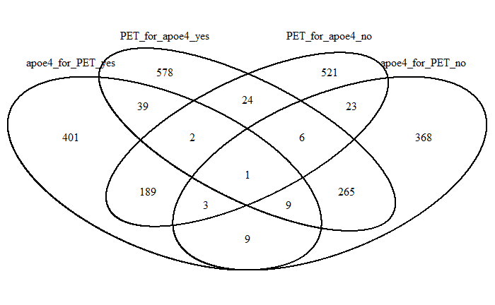

```r
library(VennDiagram)
grid.newpage()
venn <- draw.quad.venn(area1 = length(which(!is.na(sig_all2$P.Value.c1))),
               area2 = length(which(!is.na(sig_all2$P.Value.c2))),
               area3 = length(which(!is.na(sig_all2$P.Value.c3))),
               area4 = length(which(!is.na(sig_all2$P.Value.c4))),
               n12 = length(which(!is.na(sig_all2$P.Value.c1) & !is.na(sig_all2$P.Value.c2))),
               n13 = length(which(!is.na(sig_all2$P.Value.c1) & !is.na(sig_all2$P.Value.c3))),
               n14 = length(which(!is.na(sig_all2$P.Value.c1) & !is.na(sig_all2$P.Value.c4))),
               n23 = length(which(!is.na(sig_all2$P.Value.c2) & !is.na(sig_all2$P.Value.c3))),
               n24 = length(which(!is.na(sig_all2$P.Value.c2) & !is.na(sig_all2$P.Value.c4))),
               n34 = length(which(!is.na(sig_all2$P.Value.c3) & !is.na(sig_all2$P.Value.c4))),
               n123 = length(which(!is.na(sig_all2$P.Value.c1) & !is.na(sig_all2$P.Value.c2) & !is.na(sig_all2$P.Value.c3))),
               n124 = length(which(!is.na(sig_all2$P.Value.c1) & !is.na(sig_all2$P.Value.c2) & !is.na(sig_all2$P.Value.c4))),
               n134 = length(which(!is.na(sig_all2$P.Value.c1) & !is.na(sig_all2$P.Value.c3) & !is.na(sig_all2$P.Value.c4))),
               n234 = length(which(!is.na(sig_all2$P.Value.c2) & !is.na(sig_all2$P.Value.c3) & !is.na(sig_all2$P.Value.c4))),
               n1234 = length(which(!is.na(sig_all2$P.Value.c1) & !is.na(sig_all2$P.Value.c2) & !is.na(sig_all2$P.Value.c3) & !is.na(sig_all2$P.Value.c4))),
               category = c("apoe4_for_PET_yes", "apoe4_for_PET_no", "PET_for_apoe4_yes", "PET_for_apoe4_no"),
               cat.pos = c(0, 0, 0, 0))
```

```r
#               lty = "dashed",
#               cex = 2,
#               cat.cex = 2,
#               cat.col = c("skyblue", "pink1", "mediumorchid", "orange"),
#               fill = c("skyblue", "pink1", "mediumorchid", "orange"))
```

*Ask JD about this ^^*

# 2.7.1. Make Venn diagram of overlapping genes

```r
Group <- factor(exdata3$PET, levels = c("POS", "NEG"))
design2 <- model.matrix(~0 + Group)
colnames(design2) <- c("POS", "NEG")
```

–>

```r
fit3 <- lmFit(exprs, design2)
cont.matrix2 <- makeContrasts(POSvsNEG = POS - NEG, levels = design2)
fit4 <- contrasts.fit(fit3, cont.matrix2)
fit4 <- eBayes(fit4)
topTable(fit4, adjust = "BH")
```

|  | logFC | AveExpr | t | P.Value | adj.P.Val | B |
| --- | --- | --- | --- | --- | --- | --- |
| 2328611 | -0.24349043 | 6.931149 | -3.781354 | 0.0002074070 | 0.9997102 | 0.50013583 |
| 3997946 | 0.14334623 | 9.035701 | 3.648961 | 0.0003381087 | 0.9997102 | 0.07930919 |
| 2566383 | -0.08138720 | 8.334744 | -3.626837 | 0.0003664051 | 0.9997102 | 0.01024134 |
| 2694314 | 0.10608542 | 6.813847 | 3.553376 | 0.0004772006 | 0.9997102 | -0.21648884 |
| 3707258 | 0.06258903 | 6.911761 | 3.470792 | 0.0006390722 | 0.9997102 | -0.46656387 |
| 3957224 | 0.08050569 | 6.324961 | 3.469708 | 0.0006415049 | 0.9997102 | -0.46981262 |
| 3934479 | 0.07847492 | 6.465840 | 3.468142 | 0.0006450341 | 0.9997102 | -0.47450352 |
| 3819771 | 0.21167767 | 5.350143 | 3.463788 | 0.0006549411 | 0.9997102 | -0.48753481 |
| 3462630 | -0.07185294 | 3.382152 | -3.439265 | 0.0007134666 | 0.9997102 | -0.56067593 |
| 4038494 | 0.10130047 | 3.711608 | 3.427094 | 0.0007442989 | 0.9997102 | -0.59680772 |

Many of the same genes (265) are differentially expressed between: *PET pos/neg when they have the apoe4 allele; and* apoe4 yes/no when they are negative for PET

^ These must be genes that can protect against AD.

Many of the same genes (189) are also differentially expressed between: *PET pos/neg when they do not have the apoe4 allele; and* apoe4 yes/no when they are positive for PET

^ These latter genes must be acting independently of the apoe4 network to cause AD.

Find out how many people are in each group:

```r
dim(signif_PET_pos_v_neg)
```

[output not shown]

*21 December 2017*

We have carried out pairwise contrasts for PET and apoe4, but we haven’t yet compared PET-pos v PET-neg. We’ll do that now.

Create design matrix

```r
Group <- factor(exdata3$PET, levels = c("POS", "NEG"))
design2 <- model.matrix(~0 + Group)
colnames(design2) <- c("POS", "NEG")
```

Find differentially expressed genes

```r
fit3 <- lmFit(exprs, design2)
cont.matrix2 <- makeContrasts(POSvsNEG = POS - NEG, levels = design2)
fit4 <- contrasts.fit(fit3, cont.matrix2)
fit4 <- eBayes(fit4)
topTable(fit4, adjust = "BH")
```

```r
results_PETposvneg <- topTable(fit4, n = Inf)
results_PETposvneg$probe_id <- rownames(results_PETposvneg)
signif_PET_pos_v_neg <- dplyr::filter(results_PETposvneg, P.Value < 0.05)
dim(signif_PET_pos_v_neg)
```

Now for apoe4

```r
Group <- factor(exdata3$apoe4, levels = c(0, 1))
design3 <- model.matrix(~0 + Group)
colnames(design3) <- c("NEG", "POS")
```

Find differentially expressed genes

```r
fit5 <- lmFit(exprs, design3)
cont.matrix3 <- makeContrasts(apoe4 = NEG - POS, levels = design3)
fit6 <- contrasts.fit(fit5, cont.matrix3)
fit6 <- eBayes(fit6)
topTable(fit6, adjust = "BH")
```

```r
results_apoe4posvneg <- topTable(fit6, n = Inf)
results_apoe4posvneg$probe_id <- rownames(results_apoe4posvneg)
signif_apoe4_pos_v_neg <- filter(results_apoe4posvneg, P.Value < 0.05)
dim(signif_apoe4_pos_v_neg)
```

Create table of all significant differentially expressed genes

```r
sig_direct_pairs <- full_join(
  dplyr::select(signif_PET_pos_v_neg, P.Value, probe_id),
  dplyr::select(signif_apoe4_pos_v_neg, P.Value, probe_id),
  by = "probe_id") %>%
  dplyr::select(probe_id, everything())
colnames(sig_direct_pairs)[2] <- "P.Value_PET"
colnames(sig_direct_pairs)[3] <- "P.Value_apoe4"
```

```r
library(VennDiagram)
grid.newpage()
venn2 <- draw.pairwise.venn(
  area1 = length(which(!is.na(sig_direct_pairs$P.Value_PET))),
  area2 = length(which(!is.na(sig_direct_pairs$P.Value_apoe4))),
  cross.area = length(which(!is.na(sig_direct_pairs$P.Value_PET) & !is.na(sig_direct_pairs$P.Value_apoe4))),
  category = c("PET_pos_v_neg", "apoe4_pos_v_neg"),
  ext.text = FALSE, cat.prompts = T, cat.pos = 0)
```

# 2.8 Get KEGG results for PET yes/no genes

Attach gene data to PET

```r
library(tidyverse)
sig_PET_pos_v_neg <- left_join(signif_PET_pos_v_neg, pid_all, by = "probe_id")
length(which(!is.na(sig_PET_pos_v_neg$gene_symbol))) # to get number of genes with gene IDs
```

Following the vignette for the `gage` package, we create vectors of samples for PET pos and neg conditions

```r
library(gage)
pet_pos <- meta2$AIBL.Id[meta2$PET == "POS" & !is.na(meta2$PET)]
pet_neg <- meta2$AIBL.Id[meta2$PET == "NEG" & !is.na(meta2$PET)]
```

Create a matrix of ‘exdata’ only for probes that were significant and have gene_symbols (i.e. were identified)

```r
sig_probes <- sig_PET_pos_v_neg[!is.na(sig_PET_pos_v_neg$gene_symbol), 7:8]
data <- exdata[rownames(exdata) %in% sig_probes$probe_id, ]
data$probe_id <- rownames(data)
data <- dplyr::left_join(data, sig_probes, by = "probe_id")
rownames(data) <- data$gene_symbol
data$probe_id <- NULL # remove redundant columns
data$gene_symbol <- NULL
data <- data[, colnames(data) %in% exdata3$AIBL.Id] #removing NAs and outliers
data <- as.matrix(data)
str(data)
```

Create gene set input data based on significant genes found in the PET pos v neg contrast, and which also had identifiers

```r
g <- as.character(sig_PET_pos_v_neg$gene_symbol[!is.na(sig_PET_pos_v_neg$gene_symbol)]) # create vector of gene names (530 unique genes in total)
```

```
Error: object 'sig_PET_pos_v_neg' not found
```

–>

Before embarking on analysis using gage, we want to classify the significant genes into gene sets. First we attempt this using the g:GOSt function on the g:Profiler website (https://biit.cs.ut.ee/gprofiler/)

```r
write.table(sig_PET_pos_v_neg$gene_symbol[!is.na(sig_PET_pos_v_neg$gene_symbol)], "C:/Users/bre227/Documents/R/AD_project/Working/sig_PET_pos_v_neg_genes.txt",
            quote = F,
            col.names = F,
            row.names = F)
```

**Note**: According to JD, this step should be saved for later. We will therefore attach write the table of ‘sig_PET_pos_v_neg’ to save us having to run the entire script at startup every day.

```r
write.table(sig_PET_pos_v_neg,
            "C:/Users/bre227/Documents/R/AD_project/Working/sig_PET_pos_v_neg.txt",
            sep = "\t")
```

*9 January 2018*

### Meeting with JD

MolsigDB - database for gene sets applicable for different diseases.

Do correlation analysis on gene set.

Do Chi square on outcome and SNP.

- First take the AIBL SNPs, and find the other SNPs with which they are in LD. (Done)
- Second, record the genotypes of those SNPs, and use them to infer the genotypes of the SNPs with which they are in LD.
- Third, for each AIBL SNP, perform a linear model - lm(expression ~ rs#…), and lm(expression ~ rs#… + age, gender, apoe4)
- Fourth, perform Chisquares for each rs#… and PET status
- 2000 AIBL SNPs -> chisquare L1
- 18,000 LD SNPs -> chisquare L2
- **L1 + L2**

### Return to KEGG

To find the gene sets in which our significant genes lie, we can use the KEGG database, using KEGGREST (guide here: http://bioconductor.org/packages/release/bioc/vignettes/KEGGREST/inst/doc/KEGGREST-vignette.html.

```r
sig_PET_pos_v_neg <- read.table("C:/Users/bre227/Documents/R/AD_project/Working/sig_PET_pos_v_neg.txt",
                                header = T)
library(KEGGREST)
g <- as.character(sig_PET_pos_v_neg$gene_symbol[!is.na(sig_PET_pos_v_neg$gene_symbol)]) # create vector of gene names (530 unique genes in total)
kegids <- sapply(g, function(x){
  keggFind("hsa", x)})
# save to file to prevent having to run the above each time, because it is time-consuming
save(kegids, file = "C:/Users/bre227/Documents/R/AD_project/Working/kegids.RData")
```

```r
# create a table of genes and the number of hsa id hits
t <- lapply(kegids, length)
t <- data.frame(unlist(t))
t$gene <- rownames(t)
rownames(t) <- seq(nrow(t))

f <- lapply(kegids, function(x){ # pull hsa ids for all genes with only one hsa entry
  if (length(x) == 1){
    print(names(x))
  }
})

g <- data.frame(unlist(f)) # convert into data frame
g$gene <- rownames(g)

library(dplyr)
h <- left_join(t, g, by = "gene")# join with table
colnames(h)[3] <- "hsa_id"


## Test to pull out those with exact matches
#create test list
i <- kegids[c(1,2,5)]

# test to pull out the names
names(kegids$COA5[grep("\\bCOA5\\b", kegids$COA5)])
names(kegids$GATA2[grep("\\bGATA2\\b", kegids$GATA2)])
names(kegids$C21orf2[grep("\\bC21orf2\\b", kegids$C21orf2)])

# test to pull out the number of names with exact matches
length(names(kegids$COA5[grep("\\bCOA5\\b", kegids$COA5)]))
length(names(kegids$GATA2[grep("\\bGATA2\\b", kegids$GATA2)]))
length(names(kegids$C21orf2[grep("\\bC21orf2\\b", kegids$C21orf2)]))

## build script
grep("\\bCOA5\\b", kegids$COA5)
kegids$COA5[grep("\\bCOA5\\b", kegids$COA5)]
names(kegids$COA5[grep("\\bCOA5\\b", kegids$COA5)])
length(names(kegids$COA5[grep("\\bCOA5\\b", kegids$COA5)]))

paste("\\b", "COA5", "\\b", sep = "") # works

lapply(i, function(x){ # pastes each element
  paste("\\b", x, "\\b", sep = "")
})

lapply(names(i), function(x){ # pastes just the name
  paste("\\b", x, "\\b", sep = "")
})

# try creating a vector of the pasted names and use that to match

n <- sapply(names(kegids), function(x){ # creates character vector. Need to remove quotes and replace with |
  print(paste("\\b", x, "\\b", sep = ""), quote = F)
})

n <- paste(c(n), collapse = "|") # to create one-character vector separated by "|"

# test with COA5
kegids$COA5 # prints both entries
kegids$COA5[grep(n, kegids$COA5)] # prints only the one of interest

# again, with GATA2
kegids$GATA2
kegids$GATA2[grep(n, kegids$GATA2)] # prints both entries (as expected)

# again, with C21orf2
kegids$C21orf2 # prints all 8 entries
kegids$C21orf2[grep(n, kegids$C21orf2)] # prints only the one of interest

# check whether it prints the right lengths
lapply(i, function(x){
  length(names(x[grep(n, x)]))
})

# check whether it returns logical results
lapply(i, function(x){
  length(names(x[grep(n, x)])) == 1
})

# try to get it to print those that satisfy the condition

lapply(i, function(x){
  if (length(names(x[grep(n, x)])) == 1){
    print(names(x[grep(n, x)]))
  }
})

# run over whole set
o <- lapply(kegids, function(x){
  if (length(names(x[grep(n, x)])) == 1){
    print(names(x[grep(n, x)]))
  }
})

# convert to data frame
p <- data.frame(unlist(o))
p$gene <- rownames(p)

# join to data frame
q <- dplyr::left_join(h, p, by = "gene")

length(which(!is.na(q$hsa_id)))
length(which(!is.na(q$unlist.o)))

# to test there are no values in $hsa_id that are not in $unlist.o.
which(is.na(q$unlist.o.) & !is.na(q$hsa_id))
```

so there are still 89 with multiple hsa_id hits, even with exact matching. What is going on there?

e.g. GATA2 picks up GATA2-AS1. Also, [18] PAG1 should only have one hit! When using the collapsed name vector ‘n’, you get two hits, but when using “\bPAG1\b” you get just one. This must be because there is another gene in ‘n’ that is getting a hit in the PAG1 entry.

```r
names(kegids$PAG1)[grep(n, kegids$PAG1)]
names(kegids$PAG1)[grep("\\bPAG1\\b", kegids$PAG1)]
```

Following this: https://stackoverflow.com/questions/29223862/r-regex-grep-excluding-hyphen-dash-as-boundary, we’ll try using a different boundary.

```r
r <- sapply(names(kegids), function(x){ # creates character vector. Need to remove quotes and replace with |
  print(paste("\\b", x, "(?=$|,)", sep = ""), quote = F)
})

r <- paste(c(r), collapse = "|")

s <- lapply(kegids, function(x){
  if (length(names(x[grep(r, x)])) == 1){
    print(names(x[grep(r, x)]))
  }
})

t <- data.frame(unlist(s))
t$gene <- rownames(t)
q <- left_join(q, t, by = "gene")

which(is.na(q$unlist.o.) & !is.na(q$unlist.s.))
```

Ok, so we got two more hits. This just isn’t satisfactory. Let’s try converting each entry into a data frame, and then grepping it for the hit.

```r
for (x in names(i)){
  y <- print(x)
  paste("\\b", get(y), "\\b")
}

df1 <- data.frame(x=c(1:5),y=c(11:15))
df2 <- data.frame(x=c(1:5),y=c(11:15))
mylist <- list(df1=df1,df2=df2)

mylist1 <- lapply(seq_along(mylist),
        function(i, x){
            x[[i]]$id <- i
            return (x[[i]])
        }, mylist
)

mylist2 <- lapply(names(mylist),
    function(n, x){
        x[[n]]$id <- n
        return (x[[n]])
    }, mylist
)


# Create additional variable inside each element with index name
ii <- lapply(names(i),
             function(n, x){
               x[[n]]$id <- n
               return (x[[n]])
             }, i
             )

names(ii[[1]])[grep(paste("\\b", ii[[1]]$id, "\\b", sep = ""), ii[[1]])]
names(ii[[2]])[grep(paste("\\b", ii[[2]]$id, "\\b", sep = ""), ii[[2]])]
names(ii[[2]])[grep(paste("\\b", ii[[2]]$id, "(?=$|,)", sep = ""), ii[[2]], perl = T)] ## this works to exclude hyphens!!

# create a new vector using this new grep expression
u <- sapply(names(kegids), function(x){
  print(paste("\\b", x, "(?=$|,)", sep = ""), quote = F)
})
u <- paste(c(u), collapse = "|")

# test with 'ii' - remember to add "perl = T" to the grep function, and change from 1 to 2 matches (to account for the newly created id)
v <- lapply(ii, function(x){
  if (length(names(x[grep(n, x, perl = T)])) == 2){
    print(names(x[grep(n, x, perl = T)]))
  }
}) # doesn't work very well - didn't capture GATA2


x <- list(a=11,b=12,c=13)
lapply(seq_along(x), function(y, n, i) { paste(n[[i]], y[[i]]) }, y=x, n=names(x))

lapply(seq_along(x), function(y, n, i){
  paste(n[[i]], y[[i]])
}, y = x, n = names(x))

lapply(x, function(y, n, i){
  paste(n[[i]], y[[i]])
}, y = x, n = names(x))

x <- i
lapply(seq_along(x), function(y, n, i){
  names(x)[grep(paste("\\b", x, "(?=$|,)", sep = ""), x, perl = T)]
}, y = x, n = names(x)
)


## try again

lapply(seq_along(ii), function(y, n, i){
  paste(n[i], y[i])
}, y = ii, n = names(ii))

lapply(seq_along(ii), function(y, n, i){ # this is promising
  grep(n[[i]], y[[i]])
}, y = ii, n = names(ii))

lapply(seq_along(ii), function(x, n, i){ # this is promising
  names(x[[i]])[grep(paste("\\b", n[[i]], "(?=$|,)", sep = ""), x, perl = T)]
}, x = ii, n = names(ii))

names(ii$COA5)[grep(paste("\\b", "COA5", "(?=$|,)", sep = ""), ii, perl = T)]
names(ii$GATA2)[grep(paste("\\b", "GATA2", "(?=$|,)", sep = ""), ii, perl = T)]
names(ii$C21orf2)[grep(paste("\\b", "C21orf2", "(?=$|,)", sep = ""), ii$C21orf2, perl = T)] # this works if you specify the index. Let's try the above again, adjusting that.

lapply(seq_along(ii), function(x, n, i){
  names(x[[i]])[grep(paste("\\b", n[[i]], "(?=$|,)", sep = ""), x[[i]], perl = T)]
}, x = ii, n = names(ii)) ### THIS IS IT!!!
```

Let’s try it on the whole set

```r
w <- lapply(seq_along(kegids), function(x, n, i){
  if (length(names(x[[i]])[grep(paste("\\b", n[[i]], "(?=$|,)", sep = ""), x[[i]], perl = T)]) == 1){
    return(names(x[[i]])[grep(paste("\\b", n[[i]], "(?=$|,)", sep = ""), x[[i]], perl = T)])
  }
}, x = kegids, n = names(kegids))

# It works, but we get some strange misses, mostly those that have only one hsa entry? It also doesn't return the index names.
# Let's try without the condition

aa <- lapply(seq_along(kegids), function(x, n, i){
  names(x[[i]])[grep(paste("\\b", n[[i]], "(?=$|,)", sep = ""), x[[i]], perl = T)]
}, x = kegids, n = names(kegids))

aaa <- lapply(seq_along(kegids), function(x, n, i){
  names(x[i])[grep(paste("\\b", n[[i]], "(?=$|,)", sep = ""), x[[i]], perl = T)]
  names(x[[i]])[grep(paste("\\b", n[[i]], "(?=$|,)", sep = ""), x[[i]], perl = T)]
}, x = kegids, n = names(kegids))

aaaa <- lapply(kegids, function(x, n, i){
  names(x[i])[grep(paste("\\b", n[[i]], "(?=$|,)", sep = ""), x[i], perl = T)]
}, x = kegids, n = names(kegids))

b <- lapply(seq_along(kegids), function(x, i){
  x[[i]][grep(paste("\\b", n[[i]], "(?=$|,)", sep = ""), x[[i]], perl = T)]
}, n = names(kegids))

lapply(seq_along(ii), function(x){
  cat(x)
})

bb <- sapply(ii, function(x){
  names(ii)
}, USE.NAMES = T)

bbb <- sapply(seq_along(kegids), function(x, n, i){
  names(x[[i]])[grep(paste("\\b", n[[i]], "(?=$|,)", sep = ""), x[[i]], perl = T)]
}, x = kegids, n = names(kegids), USE.NAMES = T)

c <- sapply(kegids, function(x, n, i){
  names(x[[i]])[grep(paste("\\b", n[[i]], "(?=$|,)", sep = ""), x[[i]], perl = T)]
}, x = kegids, n = names(kegids), USE.NAMES = T)

cc <- sapply(ii, function(x){
  paste("\\b", names[[i]], "(?=$|,)", sep = "")
}, USE.NAMES = T)

n <- names(ii)

ccc <- llply(kegids, function(x, n, i){
  if (length(names(x[[i]])) > 1){
    paste("\\b", n[[i]], "(?=$|,)", sep = "")
  }
  else {
    names(x[[i]])
  }
}, n = names(kegids))

ddd <- sapply(kegids, function(x, n, i){
  if (length(names(x)) > 1) {
    paste("\\b", names(n[[i]]), "\\b", sep = "")
  }
  else {
    names(x)
  }
}, n = kegids, i = names(kegids))


eee <- lapply(seq_along(kegids), function(x, n, i){
  if (length(names(x[[i]])[grep(paste("\\b", n[[i]], "(?=$|,)", sep = ""), x[[i]], perl = T)]) > 1){
    names(x[[i]])[grep(paste("\\b", n[[i]], "(?=$|,)", sep = ""), x[[i]], perl = T)]
  }
  else {
    names(x[[i]])
  }
}, x = kegids, n = names(kegids))

fff <- imap(ii, function(x, y){
  length(names(ii))
})


c <- list(names(kegids))
```

## Code by JD

```r
l1=lapply(kegids, function(x) {
A=list()
A1=list()
for(i in 1:nrow(data.frame(x,stringsAsFactors = F))){
 if(nrow(x)>1){
    A[i] <- grep(paste("\\b", names(x), "(?=$|,)", sep = ""),data.frame(x,stringsAsFactors = F)[i,],value=T,perl=T)
    A1[i] <- ifelse(is.null(A[i])==T,"NULL",rownames(x))
 } else {
   A1[i]=rownames(x)
 }
}
})
```

```r
l1=lapply(ii, function(x) {
A=list()
A1=list()
for(i in 1:nrow(data.frame(x,stringsAsFactors = F))){
 if(nrow(data.frame(x,stringsAsFactors = F)) > 1){
    A[i] <- grep(paste("\\b", names(x), "(?=$|,)", sep = ""),data.frame(x,stringsAsFactors = F)[i,],value=T,perl=T)
    A1[i] <- ifelse(is.null(A[i])==T,"NULL",rownames(x))
 } else {
   A1[i]=rownames(x)
 }
}
})

l2 <- lapply(ii, function(x){
  for (i in 1:nrow(data.frame(x, stringsAsFactors = F))){
    return(rownames(x))
  }
})

l3 = list()
for (i in x){
  l3[i] <- names(x)
}

lapply(x, function(x, n){
  names(x)
  names(n)
}, n = names(x))


l4 <- lapply(ii, function(x){

  names(x[i])
})

A = list()
for (i in ii){
A[i] <- names(ii)
}
```

```r
library(plyr)
yyy <- plyr::ldply(ii, rbind)
yyy <- t(yyy)
yyy <- data.frame(yyy, stringsAsFactors = F)
colnames(yyy) <- yyy[1,]
yyy <- yyy[-1, ]
#yyy$hsa <- rownames(yyy)
#library(dplyr)
#yyy <- select(yyy, hsa, everything())
# yyy$hsa <- rownames(yyy)

grep(paste("\\b", "COA5", "\\b", sep = ""), yyy$COA5, perl = T, value = T)
grep(paste("\\b", "GATA2", "\\b(?=$|,)", sep = ""), yyy$GATA2, perl = T, value = T)


rownames(yyy)
rownames(yyy)[grep(paste("\\b", "GATA2", "\\b(?=$|,)", sep = ""), yyy$GATA2, perl = T)]


apply(yyy, 2, function(x){
  y <- colnames(x)[i]
  paste("\\b", y, "\\b(?=$|,)", sep = "")
})

sapply(yyy, function(x){ # works, but returns the rows with the gene names. Don't want that.
  grep(paste("\\b", x[1], "\\b(?=$|,)", sep = ""), x, perl = T, value = T)
})

sapply(yyy, function(x){ # works, but returns the rows with the gene names. Don't want that.
  grep(paste("\\b", colnames(x), "\\b(?=$|,)", sep = ""), x, perl = T, value = T)
})

sapply(yyy, function(x){
  colnames(x[i])
})

apply(yyy, 2, function(x){
  colnames(x)
})

sapply(colnames(yyy), function(x){ # works
  y <- paste("\\b", x, "\\b(?=$|,)", sep = "")
  grep(y, yyy[, x], perl = T, value = T)
})

sapply(colnames(yyy), function(x){ # works
  y <- paste("\\b", x, "\\b(?=$|,)", sep = "")
  rownames(yyy)[grep(y, yyy[, x], perl = T)]
})

l1 <- data.frame(sapply(colnames(yyy), function(x){ # works
  y <- paste("\\b", x, "\\b(?=$|,)", sep = "")
  rownames(yyy)[grep(y, yyy[, x], perl = T)]
}))

###

library(plyr)
kg_df <- plyr::ldply(kegids, rbind)
kg_df <- t(kg_df)
kg_df <- data.frame(kg_df, stringsAsFactors = F)
colnames(kg_df) <- kg_df[1,]
kg_df <- kg_df[-1, ]

l2 <- data.frame(sapply(colnames(kg_df), function(x){ # works
  y <- paste("\\b", x, "\\b(?=$|,)", sep = "")
  rownames(kg_df)[grep(y, kg_df[, x], perl = T)]
}))

l2 <- sapply(colnames(kg_df), function(x){ # works. But there are a few missing that shouldn't be. We need an if statement.
  y <- paste("\\b", x, "\\b(?=$|,)", sep = "")
  rownames(kg_df)[grep(y, kg_df[, x], perl = T)]
})

zzz <- kg_df[1:100, ]

sapply(colnames(kg_df), function(x){ # works. Now for the else part.
  y <- paste("\\b", x, "\\b(?=$|,)", sep = "")
  if (length(grep(x, kg_df[, x])) == 1){
    rownames(kg_df)[grep(x, kg_df[, x])]
  }
})

l1 <- sapply(colnames(kg_df), function(x){ # work. But we're still missing some we shouldn't.  Try elseif?
  if (length(grep(x, kg_df[, x])) == 1){
    rownames(kg_df)[grep(x, kg_df[, x])]
  }
  else {
    y <- paste("\\b", x, "\\b(?=$|,)", sep = "")
    rownames(kg_df)[grep(y, kg_df[, x], perl = T)]
  }
})

sapply(colnames(kg_df), function(x){
  if (length(grep(x, kg_df[, x])) == 1){
    rownames(kg_df)[grep(x, kg_df[, x])]
  }
  else {
    y <- paste("\\b", x, "\\b(?=$|,)", sep = "")
    rownames(kg_df)[grep(y, kg_df[, x], perl = T)]
  }
  else if (length(grep(y, kg_df[, x], perl = T)) > 1){
    z <- paste("\\b")
  }
})

## to investigate why some are returning too many matches, and others are still missing, we'll use the stringr package.
```

–>

```r
write.table(as.vector(rownames(exdata)),
            file = "C:/Users/bre227/Documents/R/AD_project/Working/affy_probe_ids.txt",
            quote = F,
            col.names = F,
            row.names = F)
```

Copy and paste text of file into g:Convert, and then read excel output.

```r
library(readxl)
g_probes_out <- read_excel("C:/Users/bre227/Documents/R/AD_Project/Working/affy_probe_ids_gprofiler_output.xlsx",
                           col_names = F)
dim(g_probes_out)
```

Clean the data.

```r
g_probes_out$X__2 <- gsub("AFFY_HUEX_1_0_ST_V2:", "", g_probes_out$X__2) # Remove redundant "AFFY_HUEX_1_0_ST_V2:" string from first column so that it only shows the probe ID
g_probes_out <- g_probes_out[, c(2, 5)] # remove redundant columns
g_probes_out$X__5[g_probes_out$X__5 == "N/A"] <- NA # substitute "N/A" with NA
g_probes_out <- g_probes_out[!is.na(g_probes_out$X__5), ] # remove rows with NA
length(unique(g_probes_out$X__2))
```

Remove duplicates

```r
g_prune <- g_probes_out[!duplicated(g_probes_out[c(1, 2)]),]
g_prune <- g_prune[!grepl("\\.", g_prune$X__5), ] # remove rows with ensembl transcript IDs(if that's what they are, e.g. "AC005786.1"?)
nrow(g_prune)
```

–>

```r
library(huex10sttranscriptcluster.db)
ls("package:huex10sttranscriptcluster.db")
huex10sttranscriptcluster.db
columns(huex10sttranscriptcluster.db)
help("SYMBOL")

# chromosome
x5 <- huex10sttranscriptclusterCHR
mapped_probes <- mappedkeys(x5)
xx5 <- as.list(x5[mapped_probes])
xx5.1 <- as.matrix(unlist(xx5))
chr <- xx5.1[rownames(xx5.1) %in% gns]
length(chr)

# start
x6 <- huex10sttranscriptclusterCHRLOC

x6 <- flatten(x6)

mapped_probes <- mappedkeys(x6)
xx6 <- as.list(x6[mapped_probes])
xx6.1 <- as.matrix(unlist(xx6))
start <- xx6.1[rownames(xx6.1) %in% gns]
length(str)

#end
x7 <- huex10sttranscriptclusterCHRLOCEND
mapped_probes <- mappedkeys(x7)
xx7 <- as.list(x6[mapped_probes])
xx7.1 <- as.matrix(unlist(xx7))
end <- xx7.1[rownames(xx7.1) %in% gns]
length(str)
```

–>

```r
probe_ids_ensembl <-  data.frame(xx3.1)# Convert matrix into data frame
probe_ids_ensembl$probe_ids <- rownames(probe_ids_ensembl) # create variable for probe IDs
rownames(probe_ids_ensembl) <- seq(1:nrow(probe_ids_ensembl))# make rownames a sequence 1:n

# attach ensembl IDs to significant probes

signif_apoe4_for_PET_yes <- left_join(signif_apoe4_for_PET_yes, probe_ids_ensembl, by = "probe_ids")
```

–>